# Travel Package Purchase Prediction

#### Observation

This is odd. One could infer that someone who purchases would rank the pitch higher. This variable is misleading. Why would those who rank it 1 still purchase the product? I would imagine that the higher the rank, the higher amount of True for ProdTaken. I wonder if there is an issue with collection. I will drop this variable because this seems like a collection error.

```python
# Let's drop the PitchSatisfactionScore column
data.drop(["PitchSatisfactionScore"], axis=1, inplace=True)
```

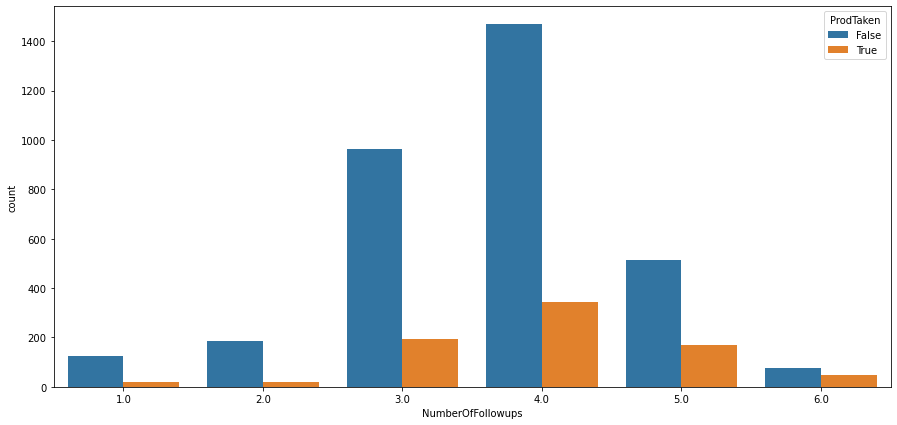

```python
# Using a countplot to show us the Marital Status in relation to ProductPitched
plt.figure(figsize=(15, 7))
ax = sns.countplot(data["NumberOfFollowups"], hue=data["ProdTaken"])
```

## Outlier Treatment

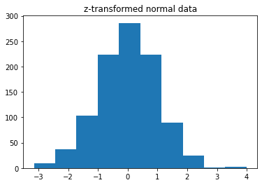

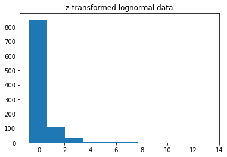

```python
# Using Z-Transformation to flag outliers in our variables
def z_transform(x):
    return (x - np.mean(x)) / np.std(x)


np.random.seed(1)
x1 = np.random.normal(size=1000)
x2 = np.random.lognormal(size=1000)


plt.hist(z_transform(x1))
plt.title("z-transformed normal data")
plt.show()


plt.hist(z_transform(x2))
plt.title("z-transformed lognormal data")
plt.show()
```

```python
# Let's flag outliers for each of the variables
def frac_outside_1pt5_IQR(x):
    length = 1.5 * np.diff(np.quantile(x, [0.25, 0.75]))
    return np.mean(np.abs(x - np.median(x)) > length)


print(frac_outside_1pt5_IQR(x1))
print(frac_outside_1pt5_IQR(x2))
```

```
0.05
0.132
```

```python
# Outliers of DurationOfPitch
quartiles = np.quantile(
    data["DurationOfPitch"][data["DurationOfPitch"].notnull()], [0.25, 0.75]
)
power_4iqr = 4 * (quartiles[1] - quartiles[0])
print(f"Q1 = {quartiles[0]}, Q3 = {quartiles[1]}, 4*IQR = {power_4iqr}")
outlier_powers1 = data.loc[
    np.abs(data["DurationOfPitch"] - data["DurationOfPitch"].median()) > power_4iqr,
    "DurationOfPitch",
]
outlier_powers1
```

```
Q1 = 9.0, Q3 = 20.0, 4*IQR = 44.0
```

```
3878    127.0
Name: DurationOfPitch, dtype: float64
```

```python
# Dropping outliers of DurationOfPitch
data.drop(outlier_powers1.index, axis=0, inplace=True)
```

```python
# Outliers of NumberOfTrips
quartiles = np.quantile(
    data["NumberOfTrips"][data["NumberOfTrips"].notnull()], [0.25, 0.75]
)
power_4iqr = 4 * (quartiles[1] - quartiles[0])
print(f"Q1 = {quartiles[0]}, Q3 = {quartiles[1]}, 4*IQR = {power_4iqr}")
outlier_powers2 = data.loc[
    np.abs(data["NumberOfTrips"] - data["NumberOfTrips"].median()) > power_4iqr,
    "NumberOfTrips",
]
outlier_powers2
```

```
Q1 = 2.0, Q3 = 4.0, 4*IQR = 8.0
```

```
385     19.0
816     21.0
2829    20.0
3260    22.0
Name: NumberOfTrips, dtype: float64
```

```python
# Dropping outliers of NumberOfTrips
data.drop(outlier_powers2.index, axis=0, inplace=True)
```

```python
# Outliers of MonthlyIncome
quartiles = np.quantile(
    data["MonthlyIncome"][data["MonthlyIncome"].notnull()], [0.25, 0.75]
)
power_4iqr = 4 * (quartiles[1] - quartiles[0])
print(f"Q1 = {quartiles[0]}, Q3 = {quartiles[1]}, 4*IQR = {power_4iqr}")
outlier_powers3 = data.loc[
    np.abs(data["MonthlyIncome"] - data["MonthlyIncome"].median()) > power_4iqr,
    "MonthlyIncome",
]
outlier_powers3
```

```
Q1 = 20751.0, Q3 = 25301.0, 4*IQR = 18200.0
```

```
142      1000.0
2482    98678.0
Name: MonthlyIncome, dtype: float64
```

```python
# Dropping outliers of MonthlyIncome
data.drop(outlier_powers3.index, axis=0, inplace=True)
```

```python
data.shape
```

```
(4121, 18)
```

#### Observations

I have now removed outlier from the variables I saw had them when doing EDA.

## Model Building

```python
# First, I always drop our target variable. In this instance, it is ProdTaken
X = data.drop(["ProdTaken"], axis=1)
Y = data["ProdTaken"]

# Building our dummies for categorical varaibles
X = pd.get_dummies(
    X,
    columns=[
        "TypeofContact",
        "CityTier",
        "Occupation",
        "Gender",
        "ProductPitched",
        "PreferredPropertyStar",
        "MaritalStatus",
        "Designation",
    ],
    drop_first=True,
)

X_train, X_test, y_train, y_test = train_test_split(
    X, Y, test_size=0.30, random_state=1
)
```

```python
# Defining function to get metrics Accuracy, Recall and Precision
def get_metrics_score(model, flag=True):
    score_list = []

    pred_train = model.predict(X_train)
    pred_test = model.predict(X_test)

    train_acc = model.score(X_train, y_train)
    test_acc = model.score(X_test, y_test)

    train_recall = metrics.recall_score(y_train, pred_train)
    test_recall = metrics.recall_score(y_test, pred_test)

    train_precision = metrics.precision_score(y_train, pred_train)
    test_precision = metrics.precision_score(y_test, pred_test)

    score_list.extend(
        (
            train_acc,
            test_acc,
            train_recall,
            test_recall,
            train_precision,
            test_precision,
        )
    )

    if flag == True:
        print("Accuracy For Training Set: ", model.score(X_train, y_train))
        print("Accuracy For Test Set: ", model.score(X_test, y_test))
        print("Recall For Training Set: ", metrics.recall_score(y_train, pred_train))
        print("Recall on test set: ", metrics.recall_score(y_test, pred_test))
        print(
            "Precision For Training Set: ", metrics.precision_score(y_train, pred_train)
        )
        print("Precision For Test Set: ", metrics.precision_score(y_test, pred_test))

    return score_list
```

```python
# Confusion Matrix function
def make_confusion_matrix(model, y_actual, labels=[1, 0]):
    y_predict = model.predict(X_test)
    cm = metrics.confusion_matrix(y_actual, y_predict, labels=[0, 1])
    df_cm = pd.DataFrame(
        cm,
        index=[i for i in ["Actual - No", "Actual - Yes"]],
        columns=[i for i in ["Predicted - No", "Predicted - Yes"]],
    )
    group_counts = ["{0:0.0f}".format(value) for value in cm.flatten()]
    group_percentages = ["{0:.2%}".format(value) for value in cm.flatten() / np.sum(cm)]
    labels = [f"{v1}\n{v2}" for v1, v2 in zip(group_counts, group_percentages)]
    labels = np.asarray(labels).reshape(2, 2)
    plt.figure(figsize=(10, 7))
    sns.heatmap(df_cm, annot=labels, fmt="")
    plt.ylabel("True label")
    plt.xlabel("Predicted label")
```

```python
# Listing X columns, or features
feature_names = list(X.columns)
print(feature_names)
```

```
['Age', 'DurationOfPitch', 'NumberOfPersonVisiting', 'NumberOfFollowups', 'NumberOfTrips', 'Passport', 'OwnCar', 'NumberOfChildrenVisiting', 'MonthlyIncome', 'TypeofContact_Self Enquiry', 'CityTier_2', 'CityTier_3', 'Occupation_Large Business', 'Occupation_Salaried', 'Occupation_Small Business', 'Ge…
```

```python
# Fitting our decision tree
dTree = DecisionTreeClassifier(criterion="gini", random_state=1)
dTree.fit(X_train, y_train)
```

```
DecisionTreeClassifier(random_state=1)
```

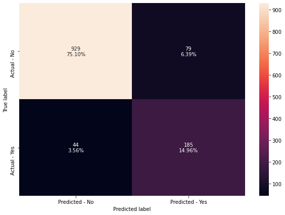

```python
# Decision tree confusion matrix
make_confusion_matrix(dTree, y_test)
```

```python
# Calculating recall score
def get_recall_score(model):
    pred_train = model.predict(X_train)
    pred_test = model.predict(X_test)
    print("Recall on training set : ", metrics.recall_score(y_train, pred_train))
    print("Recall on test set : ", metrics.recall_score(y_test, pred_test))
```

```python
# Recall score for our decision tree
get_recall_score(dTree)
```

```
Recall on training set :  1.0
Recall on test set :  0.8078602620087336
```

#### Observations

I see a recall of 81% on our test set, not horrible, but it could hopefully improve!

```python
# Accuracy for our decision tree
print("Accuracy on training set : ", dTree.score(X_train, y_train))
print("Accuracy on test set : ", dTree.score(X_test, y_test))
```

```
Accuracy on training set :  1.0
Accuracy on test set :  0.9005658852061439
```

#### Observations

This is actually quite good for our test set. 90%!

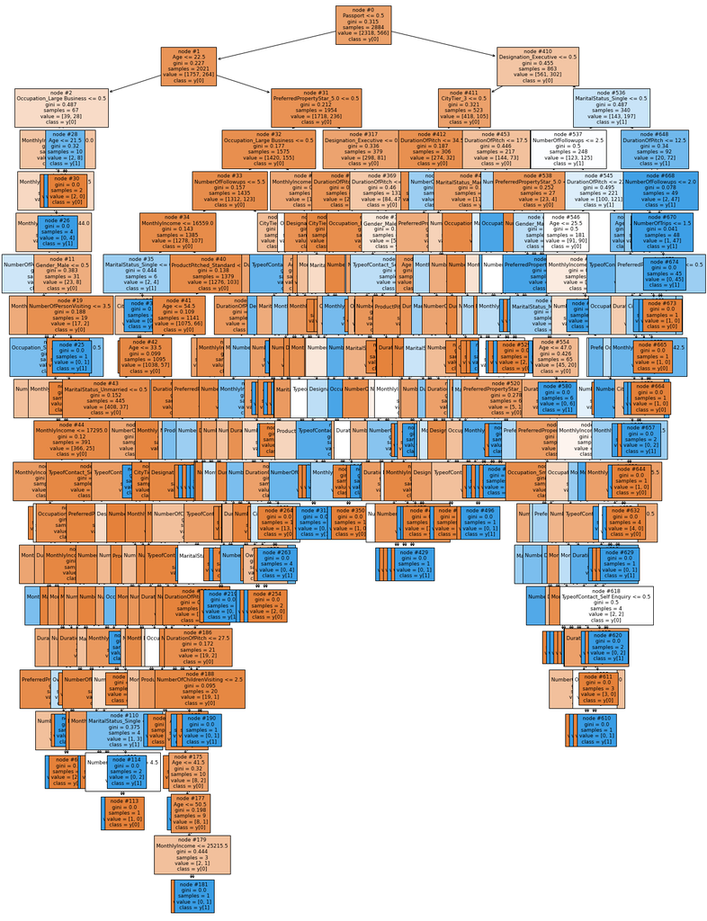

```python
# Plotting our decision tree
plt.figure(figsize=(20, 30))
tree.plot_tree(
    dTree,
    feature_names=feature_names,
    filled=True,
    fontsize=9,
    node_ids=True,
    class_names=True,
)
plt.show()
```

```python
# Text of decision tree
print(tree.export_text(dTree, feature_names=feature_names, show_weights=True))
```

```
|--- Passport <= 0.50
|   |--- Age <= 22.50
|   |   |--- Occupation_Large Business <= 0.50
|   |   |   |--- MonthlyIncome <= 21400.00
|   |   |   |   |--- MonthlyIncome <= 21295.50
|   |   |   |   |   |--- MonthlyIncome <= 17144.00
|   |   |   |   |   |   |--- NumberOfPersonVisiting <= 2.50
|   |   |   |   |   |   |   |--- weights: [0.00, 6.00] class: True
|   |   |   |   |   |   |--- NumberOfPersonVisiting >  2.50
|   |   |   |   |   |   |   |--- MonthlyIncome <= 16693.50
|   |   |   |   |   |   |   |   |--- weights: [6.00, 0.00] class: False
|   |   |   |   |   |   |   |--- MonthlyIncome >  16693.50
|   |   |   |   |   |   |   |   |--- weights: [0.00, 2.00] class: True
|   |   |   |   |   |--- MonthlyIncome >  17144.00
|   |   |   |   |   |   |--- Gender_Male <= 0.50
|   |   |   |   |   |   |   |--- Age <= 20.50
|   |   |   |   |   |   |   |   |--- weights: [4.00, 0.00] class: False
|   |   |   |   |   |   |   |--- Age >  20.50
|   |   |   |   |   |   |   |   |--- Occupation_Small Business <= 0.50
|   |   |   |   |   |   |   |   |   |--- weights: [0.00, 5.00] class: True
|   |   |   |   |   |   |   |   |--- Occupation_Small Business >  0.50
|   |   |   |   |   |   |   |   |   |--- NumberOfChildrenVisiting <= 1.50
|   |   |   |   |   |   |   |   |   |   |--- weights: [2.00, 0.00] class: False
|   |   |   |   |   |   |   |   |   |--- NumberOfChildrenVisiting >  1.50
|   |   |   |   |   |   |   |   |   |   |--- weights: [0.00, 1.00] class: True
|   |   |   |   |   |   |--- Gender_Male >  0.50
|   |   |   |   |   |   |   |--- NumberOfPersonVisiting <= 3.50
|   |   |   |   |   |   |   |   |--- Age <= 19.50
|   |   |   |   |   |   |   |   |   |--- MonthlyIncome <= 18825.00
|   |   |   |   |   |   |   |   |   |   |--- weights: [2.00, 0.00] class: False
|   |   |   |   |   |   |   |   |   |--- MonthlyIncome >  18825.00
|   |   |   |   |   |   |   |   |   |   |--- weights: [0.00, 1.00] class: True
|   |   |   |   |   |   |   |   |--- Age >  19.50
|   |   |   |   |   |   |   |   |   |--- weights: [15.00, 0.00] class: False
|   |   |   |   |   |   |   |--- NumberOfPersonVisiting >  3.50
|   |   |   |   |   |   |   |   |--- weights: [0.00, 1.00] class: True
|   |   |   |   |--- MonthlyIncome >  21295.50
|   |   |   |   |   |--- weights: [0.00, 4.00] class: True
|   |   |   |--- MonthlyIncome >  21400.00
|   |   |   |   |--- weights: [8.00, 0.00] class: False
```

[output cut: 573 more lines]

```
|   |   |   |   |   |   |--- DurationOfPitch >  8.50
|   |   |   |   |   |   |   |--- weights: [0.00, 11.00] class: True
|   |   |   |   |--- Age >  39.00
|   |   |   |   |   |--- weights: [6.00, 0.00] class: False
|   |   |   |--- DurationOfPitch >  12.50
|   |   |   |   |--- NumberOfFollowups <= 2.00
|   |   |   |   |   |--- weights: [1.00, 0.00] class: False
|   |   |   |   |--- NumberOfFollowups >  2.00
|   |   |   |   |   |--- NumberOfTrips <= 1.50
|   |   |   |   |   |   |--- PreferredPropertyStar_4.0 <= 0.50
|   |   |   |   |   |   |   |--- weights: [0.00, 2.00] class: True
|   |   |   |   |   |   |--- PreferredPropertyStar_4.0 >  0.50
|   |   |   |   |   |   |   |--- weights: [1.00, 0.00] class: False
|   |   |   |   |   |--- NumberOfTrips >  1.50
|   |   |   |   |   |   |--- weights: [0.00, 45.00] class: True
```

```python
# Variables of importance
print(
    pd.DataFrame(
        dTree.feature_importances_, columns=["Imp"], index=X_train.columns
    ).sort_values(by="Imp", ascending=False)
)
```

```
                                  Imp
Age                          0.143622
DurationOfPitch              0.132897
MonthlyIncome                0.127870
Designation_Executive        0.075289
NumberOfTrips                0.066981
Passport                     0.063941
NumberOfFollowups            0.056899
NumberOfPersonVisiting       0.042570
CityTier_3                   0.037797
TypeofContact_Self Enquiry   0.027814
OwnCar                       0.026286
PreferredPropertyStar_5.0    0.022619
MaritalStatus_Single         0.021183
Occupation_Large Business    0.017218
Gender_Male                  0.016334
MaritalStatus_Married        0.016141
MaritalStatus_Unmarried      0.015847
NumberOfChildrenVisiting     0.013133
CityTier_2                   0.012495
Occupation_Salaried          0.011149
Designation_Manager          0.010067
PreferredPropertyStar_4.0    0.009507
ProductPitched_Standard      0.009445
Designation_VP               0.006901
Occupation_Small Business    0.006776
ProductPitched_Super Deluxe  0.004993
ProductPitched_Deluxe        0.003663
Designation_Senior Manager   0.000564
ProductPitched_King          0.000000
```

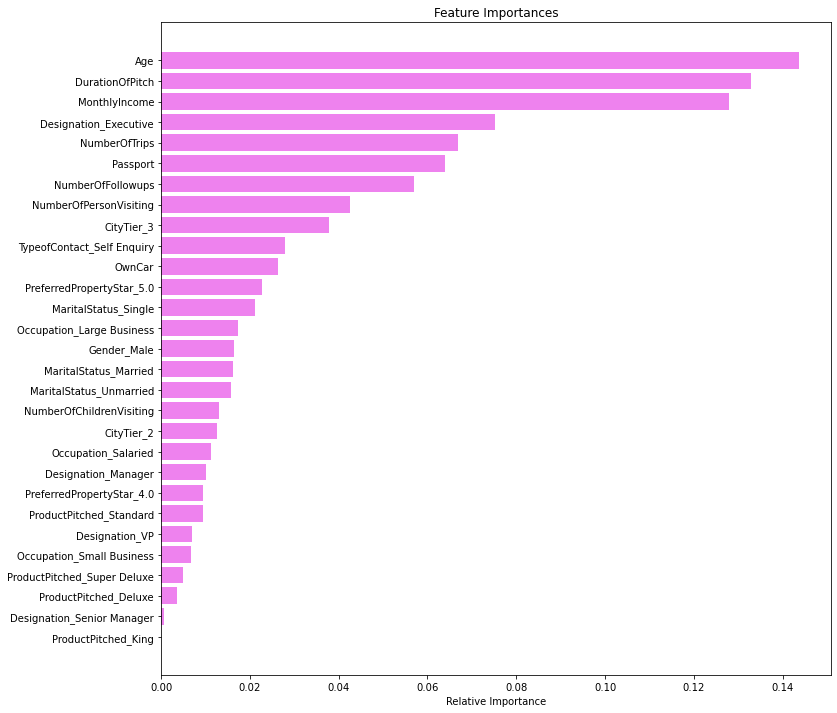

```python
importances = dTree.feature_importances_
indices = np.argsort(importances)

plt.figure(figsize=(12, 12))
plt.title("Feature Importances")
plt.barh(range(len(indices)), importances[indices], color="violet", align="center")
plt.yticks(range(len(indices)), [feature_names[i] for i in indices])
plt.xlabel("Relative Importance")
plt.show()
```

## Bagging And Random Forest

I are going to do both and compare

### Bagging

```python
# Bagging classifier base estimator
bagging_estimator = BaggingClassifier(random_state=1)
bagging_estimator.fit(X_train, y_train)
```

```
BaggingClassifier(random_state=1)
```

```python
# Showing Accuracy, Recall and Precision from our bagging estimator variable
bagging_estimator_score = get_metrics_score(bagging_estimator)
```

```
Accuracy For Training Set:  0.9906380027739251
Accuracy For Test Set:  0.9126919967663703
Recall For Training Set:  0.9558303886925795
Recall on test set:  0.6462882096069869
Precision For Training Set:  0.996316758747698
Precision For Test Set:  0.8457142857142858
```

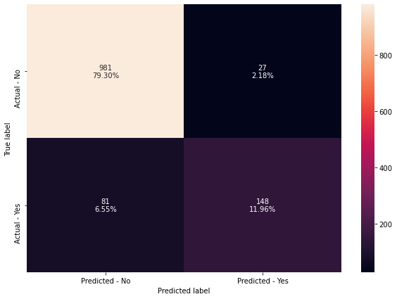

```python
# Confusion matrix of bagging estimator
make_confusion_matrix(bagging_estimator, y_test)
```

#### Observations

I have great accuracy in this model. Decision trees overfit, so this is normal. On our test, it is 91%. All things considered, this isn't a bad model

### Random Forest

```python
# Train the random forest classifier
rf_estimator = RandomForestClassifier(random_state=1)
rf_estimator.fit(X_train, y_train)
```

```
RandomForestClassifier(random_state=1)
```

```python
# Random Forest statistics: Accuracy, Recall, and Precision
rf_estimator_score = get_metrics_score(rf_estimator)
```

```
Accuracy For Training Set:  1.0
Accuracy For Test Set:  0.9240097008892482
Recall For Training Set:  1.0
Recall on test set:  0.62882096069869
Precision For Training Set:  1.0
Precision For Test Set:  0.9411764705882353
```

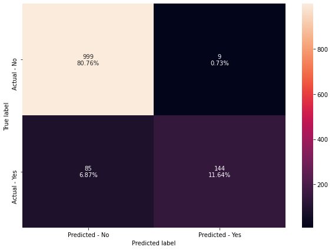

```python
# Random Forest confusion matrix
make_confusion_matrix(rf_estimator, y_test)
```

#### Observations

In Random forest, it is not too much different than bagging. I see less Type I errors, and about the same Type II variables. It overfits the data a ton. Recall is slightly lower in test test set, however. Overall, these are pretty even.

### Hyperparameters

#### Bagging

```python
# Tuning our BaggingClassifier
bagging_estimator_tuned = BaggingClassifier(random_state=1)

parameters = {
    "max_samples": [0.7, 0.8, 0.9, 1],
    "max_features": [0.7, 0.8, 0.9, 1],
    "n_estimators": [10, 20, 30, 40, 50],
}

acc_scorer = metrics.make_scorer(metrics.recall_score)

# GridSearch
grid_obj = GridSearchCV(bagging_estimator_tuned, parameters, scoring=acc_scorer, cv=5)
grid_obj = grid_obj.fit(X_train, y_train)

bagging_estimator_tuned = grid_obj.best_estimator_

bagging_estimator_tuned.fit(X_train, y_train)
```

```
BaggingClassifier(max_features=0.9, max_samples=0.9, n_estimators=50,
                  random_state=1)
```

```python
# Tuned Bagging metrics
bagging_estimator_tuned_score = get_metrics_score(bagging_estimator_tuned)
```

```
Accuracy For Training Set:  0.9996532593619972
Accuracy For Test Set:  0.9337105901374293
Recall For Training Set:  0.9982332155477032
Recall on test set:  0.7205240174672489
Precision For Training Set:  1.0
Precision For Test Set:  0.9016393442622951
```

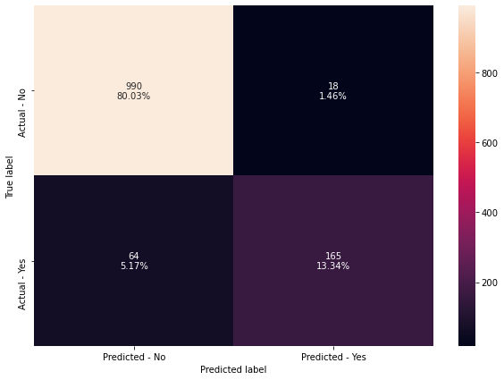

```python
# Confusion matrix of tuned model
make_confusion_matrix(bagging_estimator_tuned, y_test)
```

#### Observations

After tuning, I see some improvements. First of all, I got the best estimator

Max Features = 0.9

Max Smaples = 0.9

N Estimators = 50

```python
bagging_lr = BaggingClassifier(
    base_estimator=LogisticRegression(solver="liblinear", random_state=1),
    random_state=1,
)
bagging_lr.fit(X_train, y_train)
```

```
BaggingClassifier(base_estimator=LogisticRegression(random_state=1,
                                                    solver='liblinear'),
                  random_state=1)
```

```python
# Using our new function to get our metrics
bagging_lr_score = get_metrics_score(bagging_lr)
```

```
Accuracy For Training Set:  0.8117198335644937
Accuracy For Test Set:  0.8286176232821342
Recall For Training Set:  0.044169611307420496
Recall on test set:  0.07423580786026202
Precision For Training Set:  0.9259259259259259
Precision For Test Set:  1.0
```

#### Random Forest Tuning

```python
# Random Forest Tuning
rf_estimator_tuned = RandomForestClassifier(random_state=1)

parameters = {
    "n_estimators": [150, 200, 250],
    "min_samples_leaf": np.arange(5, 10),
    "max_features": np.arange(0.2, 0.7, 0.1),
    "max_samples": np.arange(0.3, 0.7, 0.1),
}

acc_scorer = metrics.make_scorer(metrics.recall_score)

# GridSearch
grid_obj = GridSearchCV(rf_estimator_tuned, parameters, scoring=acc_scorer, cv=5)
grid_obj = grid_obj.fit(X_train, y_train)

rf_estimator_tuned = grid_obj.best_estimator_

rf_estimator_tuned.fit(X_train, y_train)
```

```
RandomForestClassifier(max_features=0.6000000000000001, max_samples=0.5,
                       min_samples_leaf=5, n_estimators=150, random_state=1)
```

```python
# Using our function to get metrics for tuned random forest
rf_estimator_tuned_score = get_metrics_score(rf_estimator_tuned)
```

```
Accuracy For Training Set:  0.8949375866851595
Accuracy For Test Set:  0.872271624898949
Recall For Training Set:  0.5212014134275619
Recall on test set:  0.40611353711790393
Precision For Training Set:  0.9021406727828746
Precision For Test Set:  0.808695652173913
```

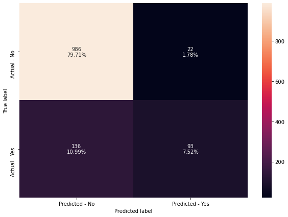

```python
# Confusion matrix of RandomForest tuned
make_confusion_matrix(rf_estimator_tuned, y_test)
```

```python
# Weighting Random Forest
rf_estimator_weighted = RandomForestClassifier(random_state=1)

parameters = {
    "class_weight": [{0: 0.3, 1: 0.7}],
    "n_estimators": [100, 150, 200, 250],
    "min_samples_leaf": np.arange(5, 10),
    "max_features": np.arange(0.2, 0.7, 0.1),
    "max_samples": np.arange(0.3, 0.7, 0.1),
}

acc_scorer = metrics.make_scorer(metrics.recall_score)

# Run the grid search
grid_obj = GridSearchCV(rf_estimator_weighted, parameters, scoring=acc_scorer, cv=5)
grid_obj = grid_obj.fit(X_train, y_train)

rf_estimator_weighted = grid_obj.best_estimator_

rf_estimator_weighted.fit(X_train, y_train)
```

```
RandomForestClassifier(class_weight={0: 0.3, 1: 0.7},
                       max_features=0.6000000000000001,
                       max_samples=0.6000000000000001, min_samples_leaf=9,
                       n_estimators=150, random_state=1)
```

```python
# Showing Accuracy, Recall and Precision from our Random Forest weighted model
rf_estimator_weighted_score = get_metrics_score(rf_estimator_weighted)
```

```
Accuracy For Training Set:  0.8914701803051318
Accuracy For Test Set:  0.8561034761519806
Recall For Training Set:  0.6908127208480566
Recall on test set:  0.5982532751091703
Precision For Training Set:  0.7391304347826086
Precision For Test Set:  0.6143497757847534
```

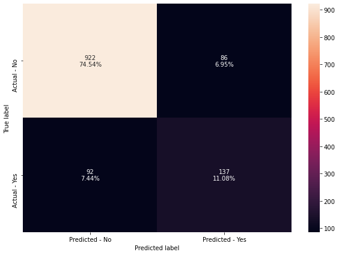

```python
# Confusion Matrix of weight random forest
make_confusion_matrix(rf_estimator_weighted, y_test)
```

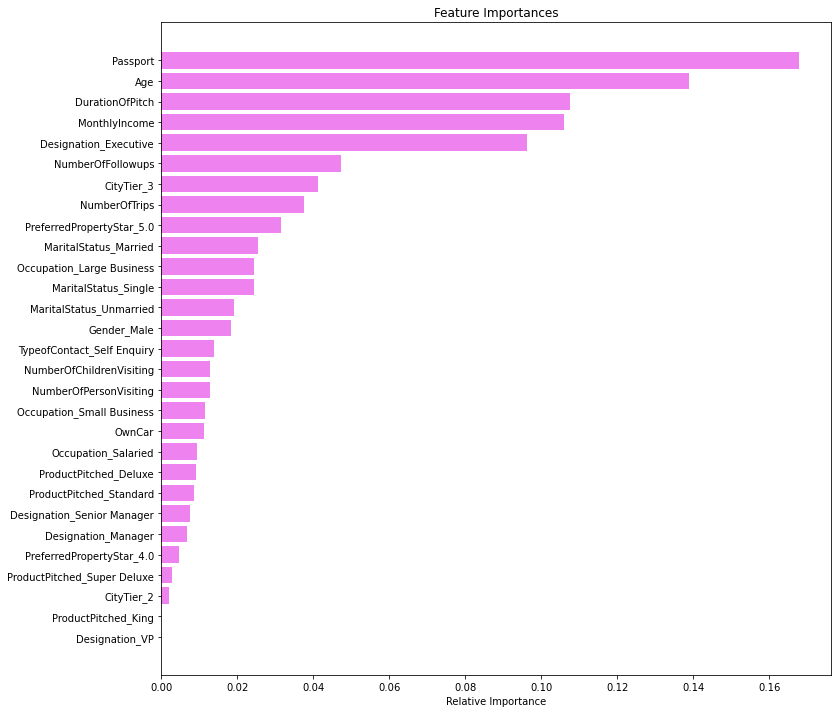

```python
importances = rf_estimator_weighted.feature_importances_
indices = np.argsort(importances)
feature_names = list(X.columns)

plt.figure(figsize=(12, 12))
plt.title("Feature Importances")
plt.barh(range(len(indices)), importances[indices], color="violet", align="center")
plt.yticks(range(len(indices)), [feature_names[i] for i in indices])
plt.xlabel("Relative Importance")
plt.show()
```

#### Observations

I see the list of important features. Passport, then Age, then duration of pitch lead to the success of purchase. These are different variables than our previous Feature Importances I have calculated.

## Boosting

### Adaboost

```python
abc = AdaBoostClassifier(random_state=1)
abc.fit(X_train, y_train)
```

```
AdaBoostClassifier(random_state=1)
```

```python
# Using our function to get metrics for the set
abc_score = get_metrics_score(abc)
```

```
Accuracy For Training Set:  0.852635228848821
Accuracy For Test Set:  0.8439773645917542
Recall For Training Set:  0.3763250883392226
Recall on test set:  0.32751091703056767
Precision For Training Set:  0.7473684210526316
Precision For Test Set:  0.6578947368421053
```

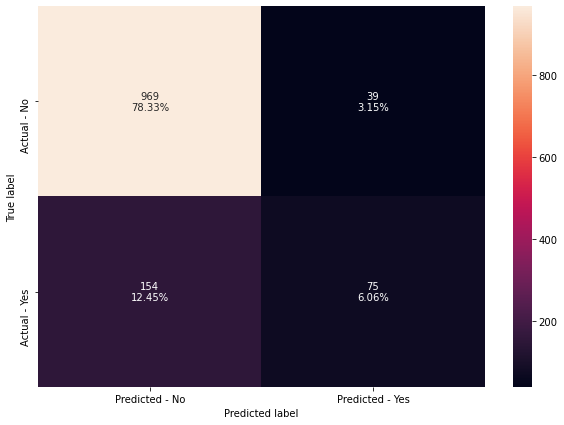

```python
make_confusion_matrix(abc, y_test)
```

### Gradient Boost

```python
gbc = GradientBoostingClassifier(random_state=1)
gbc.fit(X_train, y_train)
```

```
GradientBoostingClassifier(random_state=1)
```

```python
# Using our function to get metrics for the set
gbc_score = get_metrics_score(gbc)
```

```
Accuracy For Training Set:  0.8873092926490985
Accuracy For Test Set:  0.8674211802748585
Recall For Training Set:  0.5106007067137809
Recall on test set:  0.462882096069869
Precision For Training Set:  0.857566765578635
Precision For Test Set:  0.7210884353741497
```

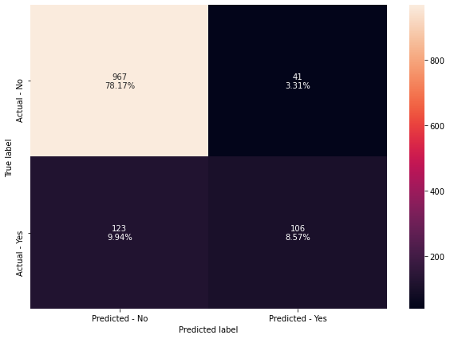

```python
make_confusion_matrix(gbc, y_test)
```

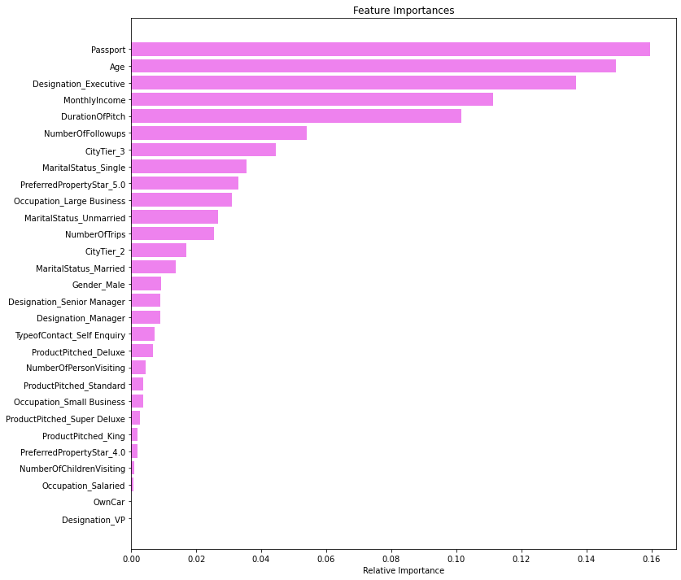

```python
# Listing the feature importances in orderr for this model
importances = gbc.feature_importances_
indices = np.argsort(importances)
feature_names = list(X.columns)

plt.figure(figsize=(12, 12))
plt.title("Feature Importances")
plt.barh(range(len(indices)), importances[indices], color="violet", align="center")
plt.yticks(range(len(indices)), [feature_names[i] for i in indices])
plt.xlabel("Relative Importance")
plt.show()
```

### XGBoost

```python
xgb = XGBClassifier(random_state=1, eval_metric="logloss")
xgb.fit(X_train, y_train)
```

```
XGBClassifier(base_score=0.5, booster='gbtree', colsample_bylevel=1,
              colsample_bynode=1, colsample_bytree=1, eval_metric='logloss',
              gamma=0, gpu_id=-1, importance_type='gain',
              interaction_constraints='', learning_rate=0.300000012,
              max_delta_step=0, max_depth=6, min_child_weight=1, missing=nan,
              monotone_constraints='()', n_estimators=100, n_jobs=20,
              num_parallel_tree=1, random_state=1, reg_alpha=0, reg_lambda=1,
              scale_pos_weight=1, subsample=1, tree_method='exact',
              validate_parameters=1, verbosity=None)
```

```python
# Using our function to get metrics for the set
xgb_score = get_metrics_score(xgb)
```

```
Accuracy For Training Set:  0.9996532593619972
Accuracy For Test Set:  0.9272433306386418
Recall For Training Set:  0.9982332155477032
Recall on test set:  0.7248908296943232
Precision For Training Set:  1.0
Precision For Test Set:  0.8601036269430051
```

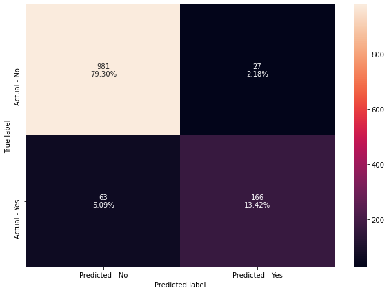

```python
make_confusion_matrix(xgb, y_test)
```

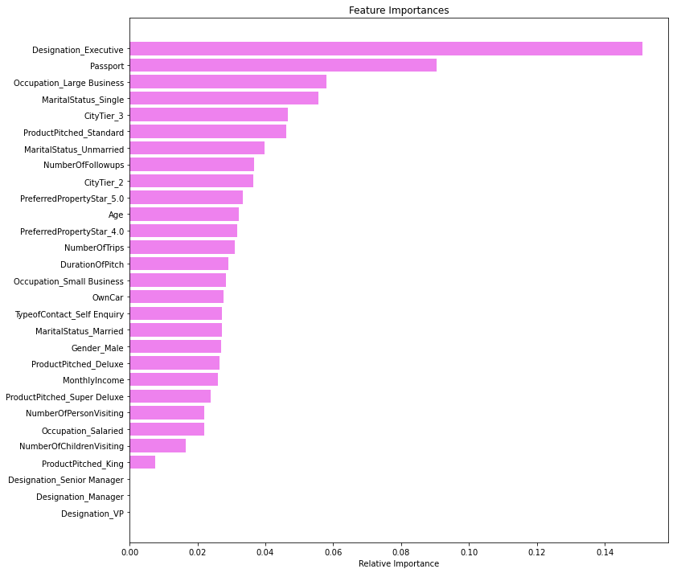

```python
# Listing the feature importances in orderr for this model
importances = xgb.feature_importances_
indices = np.argsort(importances)
feature_names = list(X.columns)

plt.figure(figsize=(12, 12))
plt.title("Feature Importances")
plt.barh(range(len(indices)), importances[indices], color="violet", align="center")
plt.yticks(range(len(indices)), [feature_names[i] for i in indices])
plt.xlabel("Relative Importance")
plt.show()
```

### Tuning Our Boosted Models

#### I am going to tune these before making a recommendation

#### Adaboost

```python
# Tuned AdaBoost
abc_tuned = AdaBoostClassifier(random_state=1)


parameters = {
    "base_estimator": [
        DecisionTreeClassifier(max_depth=1, random_state=1),
        DecisionTreeClassifier(max_depth=2, random_state=1),
        DecisionTreeClassifier(max_depth=3, random_state=1),
    ],
    "n_estimators": np.arange(10, 110, 10),
    "learning_rate": np.arange(0.1, 2, 0.1),
}


acc_scorer = metrics.make_scorer(metrics.recall_score)


grid_obj = GridSearchCV(abc_tuned, parameters, scoring=acc_scorer, cv=5)
grid_obj = grid_obj.fit(X_train, y_train)


abc_tuned = grid_obj.best_estimator_

abc_tuned.fit(X_train, y_train)
```

```
AdaBoostClassifier(base_estimator=DecisionTreeClassifier(max_depth=3,
                                                         random_state=1),
                   learning_rate=1.2000000000000002, n_estimators=100,
                   random_state=1)
```

```python
# Using our function to get metrics for the set
abc_tuned_score = get_metrics_score(abc_tuned)
```

```
Accuracy For Training Set:  0.9961858529819695
Accuracy For Test Set:  0.8860145513338723
Recall For Training Set:  0.9840989399293286
Recall on test set:  0.6419213973799127
Precision For Training Set:  0.9964221824686941
Precision For Test Set:  0.7135922330097088
```

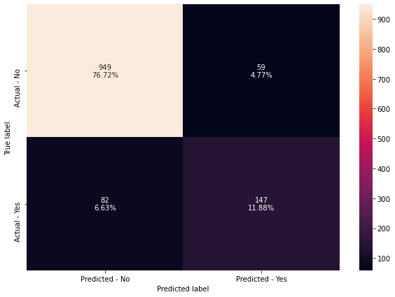

```python
# AdaBoost Confusion Matrix
make_confusion_matrix(abc_tuned, y_test)
```

#### Observations

Tune Adaboost still has some Type I and Type II errors.

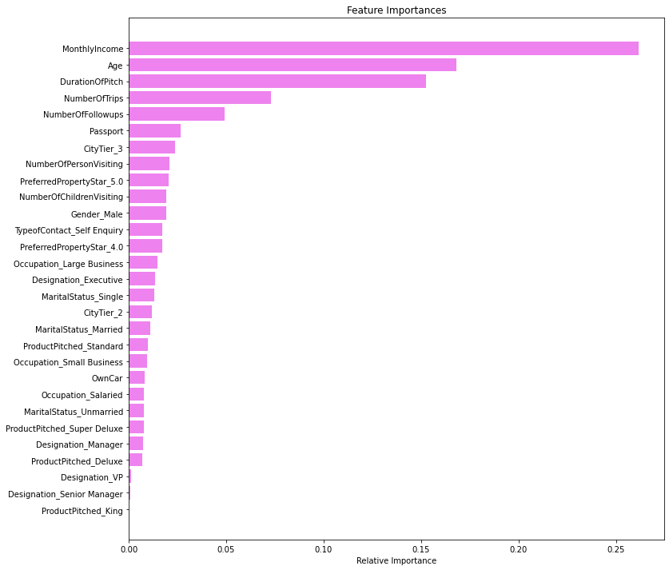

```python
# Listing the feature importances in order for this model
importances = abc_tuned.feature_importances_
indices = np.argsort(importances)
feature_names = list(X.columns)

plt.figure(figsize=(12, 12))
plt.title("Feature Importances")
plt.barh(range(len(indices)), importances[indices], color="violet", align="center")
plt.yticks(range(len(indices)), [feature_names[i] for i in indices])
plt.xlabel("Relative Importance")
plt.show()
```

#### Observations

I see that Income, Age, and DurationOfPitch are most important features for this tuned model.

#### Gradient

```python
gbc_init = GradientBoostingClassifier(
    init=AdaBoostClassifier(random_state=1), random_state=1
)
gbc_init.fit(X_train, y_train)
```

```
GradientBoostingClassifier(init=AdaBoostClassifier(random_state=1),
                           random_state=1)
```

```python
# Using our function to get metrics for the set
gbc_init_score = get_metrics_score(gbc_init)
```

```
Accuracy For Training Set:  0.8862690707350902
Accuracy For Test Set:  0.8698464025869038
Recall For Training Set:  0.5017667844522968
Recall on test set:  0.4759825327510917
Precision For Training Set:  0.8606060606060606
Precision For Test Set:  0.7266666666666667
```

#### Observations

This model does not have very good metrics. Recall is quite bad on this model.

```python
# Gradient Boosting
gbc_tuned = GradientBoostingClassifier(
    init=AdaBoostClassifier(random_state=1), random_state=1
)


parameters = {
    "n_estimators": [100, 150, 200, 250],
    "subsample": [0.8, 0.9, 1],
    "max_features": [0.7, 0.8, 0.9, 1],
}


acc_scorer = metrics.make_scorer(metrics.recall_score)


grid_obj = GridSearchCV(gbc_tuned, parameters, scoring=acc_scorer, cv=5)
grid_obj = grid_obj.fit(X_train, y_train)


gbc_tuned = grid_obj.best_estimator_


gbc_tuned.fit(X_train, y_train)
```

```
GradientBoostingClassifier(init=AdaBoostClassifier(random_state=1),
                           max_features=0.7, n_estimators=250, random_state=1,
                           subsample=0.8)
```

```python
# Using our function to get metrics for the set
gbc_tuned_score = get_metrics_score(gbc_tuned)
```

```
Accuracy For Training Set:  0.9334257975034674
Accuracy For Test Set:  0.8771220695230396
Recall For Training Set:  0.7031802120141343
Recall on test set:  0.5327510917030568
Precision For Training Set:  0.943127962085308
Precision For Test Set:  0.7305389221556886
```

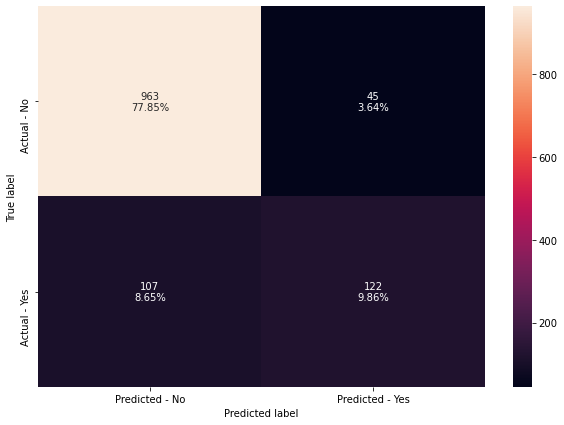

```python
# Gradient Boost Confusion Matrix
make_confusion_matrix(gbc_tuned, y_test)
```

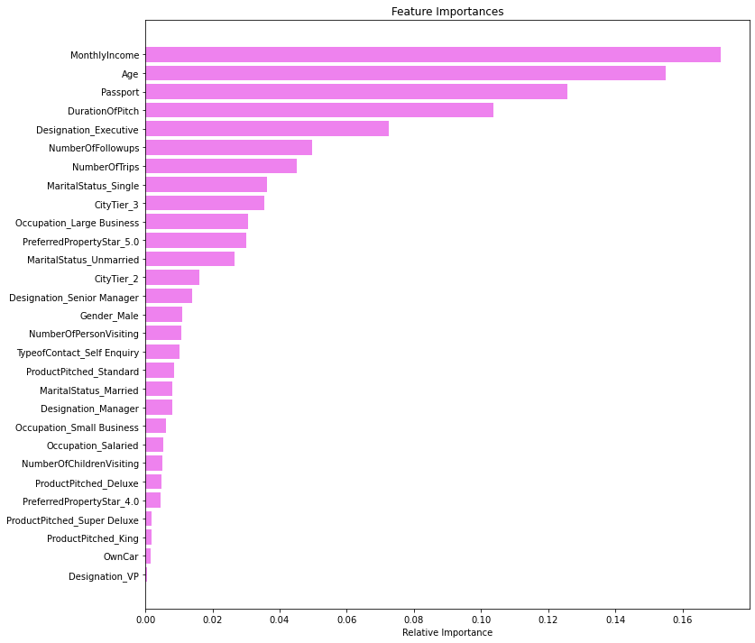

```python
# Listing the feature importances in order for this model
importances = gbc_tuned.feature_importances_
indices = np.argsort(importances)
feature_names = list(X.columns)

plt.figure(figsize=(12, 12))
plt.title("Feature Importances")
plt.barh(range(len(indices)), importances[indices], color="violet", align="center")
plt.yticks(range(len(indices)), [feature_names[i] for i in indices])
plt.xlabel("Relative Importance")
plt.show()
```

#### XGBoost Tuned is not being completed due to signficant run time.

#### Tuning our Decision Tree

```python
# Decision Tree
dtree_tuned = DecisionTreeRegressor(random_state=1)

parameters = {
    "max_depth": list(np.arange(2, 20)) + [None],
    "min_samples_leaf": [1, 3, 5, 7, 10],
    "max_leaf_nodes": [2, 3, 5, 10, 15] + [None],
    "min_impurity_decrease": [0.001, 0.01, 0.1, 0.0],
}


scorer = metrics.make_scorer(metrics.r2_score)

grid_obj = GridSearchCV(dtree_tuned, parameters, scoring=scorer, cv=5)
grid_obj = grid_obj.fit(X_train, y_train)


dtree_tuned = grid_obj.best_estimator_


dtree_tuned.fit(X_train, y_train)
```

```
DecisionTreeRegressor(max_depth=7, min_samples_leaf=10, random_state=1)
```

```python
# Listing the feature importances in order for this model
print(
    pd.DataFrame(
        dtree_tuned.feature_importances_, columns=["Imp"], index=X_train.columns
    ).sort_values(by="Imp", ascending=False)
)
```

```
                                  Imp
Designation_Executive        0.182852
Passport                     0.152591
Age                          0.126347
DurationOfPitch              0.123441
MonthlyIncome                0.058490
NumberOfFollowups            0.048158
CityTier_3                   0.043837
MaritalStatus_Single         0.036909
MaritalStatus_Married        0.029978
Gender_Male                  0.027616
Designation_Senior Manager   0.025286
NumberOfTrips                0.023186
Occupation_Large Business    0.022658
PreferredPropertyStar_5.0    0.021307
OwnCar                       0.018329
TypeofContact_Self Enquiry   0.017110
Occupation_Small Business    0.016280
MaritalStatus_Unmarried      0.015073
CityTier_2                   0.005547
Occupation_Salaried          0.002361
ProductPitched_King          0.001458
NumberOfChildrenVisiting     0.001186
ProductPitched_Standard      0.000000
ProductPitched_Super Deluxe  0.000000
PreferredPropertyStar_4.0    0.000000
ProductPitched_Deluxe        0.000000
Designation_Manager          0.000000
NumberOfPersonVisiting       0.000000
Designation_VP               0.000000
```

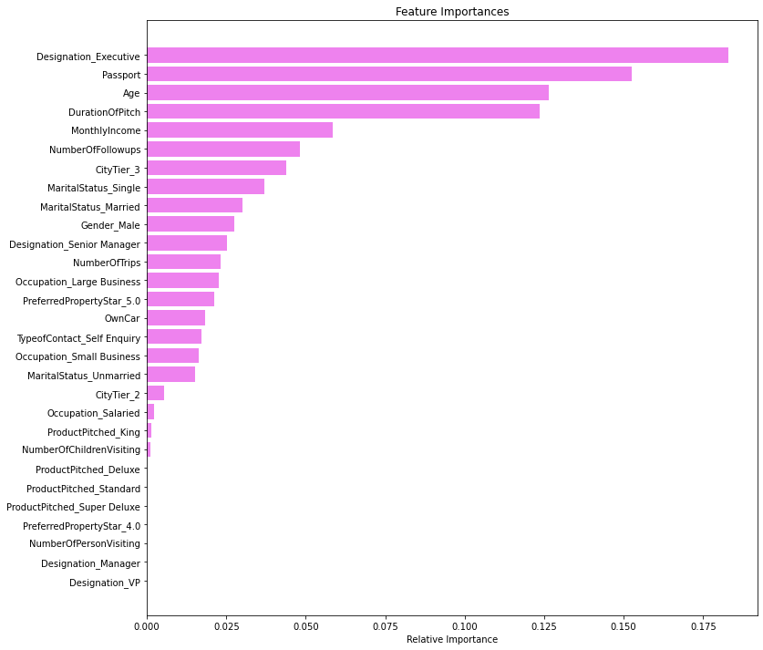

```python
feature_names = X_train.columns
importances = dtree_tuned.feature_importances_
indices = np.argsort(importances)

plt.figure(figsize=(12, 12))
plt.title("Feature Importances")
plt.barh(range(len(indices)), importances[indices], color="violet", align="center")
plt.yticks(range(len(indices)), [feature_names[i] for i in indices])
plt.xlabel("Relative Importance")
plt.show()
```

### A Comparison of Our Models

```python
# defining list of models
models = [
    bagging_estimator,
    bagging_estimator_tuned,
    bagging_lr,
    rf_estimator,
    rf_estimator_tuned,
    rf_estimator_weighted,
    abc,
    abc_tuned,
    gbc,
    gbc_init,
    gbc_tuned,
    xgb,
]

# defining empty lists to add train and test results
acc_train = []
acc_test = []
recall_train = []
recall_test = []
precision_train = []
precision_test = []

for model in models:
    j = get_metrics_score(model, False)
    acc_train.append(np.round(j[0], 2))
    acc_test.append(np.round(j[1], 2))
    recall_train.append(np.round(j[2], 2))
    recall_test.append(np.round(j[3], 2))
    precision_train.append(np.round(j[4], 2))
    precision_test.append(np.round(j[5], 2))
```

```python
comparison_frame = pd.DataFrame(
    {
        "Model": [
            "Bagging classifier with default parameters",
            "Tuned Bagging Classifier",
            "Bagging classifier with base_estimator=LR",
            "Random Forest with default parameters",
            "Tuned Random Forest Classifier",
            "Random Forest with class_weights",
            "AdaBoost with default parameters",
            "AdaBoost Tuned",
            "Gradient Boosting with default parameters",
            "Gradient Boosting with init=AdaBoost",
            "Gradient Boosting Tuned",
            "XGBoost with default parameters",
        ],
        "Train_Accuracy": acc_train,
        "Test_Accuracy": acc_test,
        "Train_Recall": recall_train,
        "Test_Recall": recall_test,
        "Train_Precision": precision_train,
        "Test_Precision": precision_test,
    }
)
comparison_frame
```

|  | Model | Train_Accuracy | Test_Accuracy | Train_Recall | Test_Recall | Train_Precision | Test_Precision |
| --- | --- | --- | --- | --- | --- | --- | --- |
| 0 | Bagging classifier with default parameters | 0.99 | 0.91 | 0.96 | 0.65 | 1.00 | 0.85 |
| 1 | Tuned Bagging Classifier | 1.00 | 0.93 | 1.00 | 0.72 | 1.00 | 0.90 |
| 2 | Bagging classifier with base_estimator=LR | 0.81 | 0.83 | 0.04 | 0.07 | 0.93 | 1.00 |
| 3 | Random Forest with default parameters | 1.00 | 0.92 | 1.00 | 0.63 | 1.00 | 0.94 |
| 4 | Tuned Random Forest Classifier | 0.89 | 0.87 | 0.52 | 0.41 | 0.90 | 0.81 |
| 5 | Random Forest with class_weights | 0.89 | 0.86 | 0.69 | 0.60 | 0.74 | 0.61 |
| 6 | AdaBoost with default parameters | 0.85 | 0.84 | 0.38 | 0.33 | 0.75 | 0.66 |
| 7 | AdaBoost Tuned | 1.00 | 0.89 | 0.98 | 0.64 | 1.00 | 0.71 |
| 8 | Gradient Boosting with default parameters | 0.89 | 0.87 | 0.51 | 0.46 | 0.86 | 0.72 |
| 9 | Gradient Boosting with init=AdaBoost | 0.89 | 0.87 | 0.50 | 0.48 | 0.86 | 0.73 |
| 10 | Gradient Boosting Tuned | 0.93 | 0.88 | 0.70 | 0.53 | 0.94 | 0.73 |
| 11 | XGBoost with default parameters | 1.00 | 0.93 | 1.00 | 0.72 | 1.00 | 0.86 |

#### An Analysis of these Models

I am strictly looking at the Test columns. All of them do well in regards to Accuracy.

after tuning the random forest model, I see a DECREASE in model performance across ALL metrics.

### Recommendation and Conclusion

Based on EDA and modeling, I can see the following regarding each package:

*Basic*: This is, generally speaking, for someone in their 20's and 30's who does not make very much money. The executive designation is most likely to get this package. The Executive Designation purchases this package.

*Deluxe*: This is for someone who is mainly in their 30's who makes more than the Basic's demographic, and is willing to splurge on a nicer package. The Manager purchases this package.

*King*: This package markets to the highest spenders, who are generally middle aged. The VP purchases this package.

*Standard*: There is a decent amount of Overlap between standard and deluxe. Both cater to the same age, and income level. However, you are going to see someone in the Senior Manager position get standard. This leads me to think that it is slightly more expensive.

*Super Deluxe*: These are the AVPs. These buyers tender to be older. Very high income, but not as high as the VP's who purchase King.

*Other Observations*:

Occupation: Free lancers are very rare. It is tough to determine based on the small sample size.

Gender: I do not see any correlation with Gender and a specific product/package.

MaritalStatus: Unmarried people do not purchase the King or Super Deluxe models.

*Product Conversion Percentages*:

Basic: 43%

Deluxe: 13%

King: 9%

Standard: 20%

Super Deluxe: 9%

I like the Tuned Bagging Classifier model, that I obtained in our test set: 93% Accuracy, 72% Recall, and 90% Precision. This would maybe be improved if time is alotted to complete a fully tuned XGBoost model, as the XGBoost model gave us the 2nd best metrics.

I recommmend that the company takes into account the aformentioned observations regarding each package, and market accordingly. The demographic provided will save time, money, and increase conversion if marketed properly.